# Modelo machine learning - Previsão de casas - AMES

# 13) Métricas para o modelo de regressão linear

- RMSE: Raiz do erro quadrático médio
- MAE: Erro absoluto médio
- MSE: Erro médio quadrático
- MAPE: Erro Percentual Absoluto Médio
- R2: O R-Quadrado, ou Coeficiente de Determinação, é uma métrica que visa expressar a quantidade da variança dos dados.

```python
# Importando bibliotecas verificações das métricas

from math import sqrt
from sklearn.metrics import r2_score
from sklearn.metrics import mean_absolute_percentage_error
from sklearn.metrics import mean_squared_error
from sklearn.metrics import mean_absolute_error
from sklearn.metrics import mean_squared_error

rmse = np.sqrt(mean_squared_error(y_test, model_linear_pred))
mae = mean_absolute_error(y_test, model_linear_pred)
mape = mean_absolute_percentage_error(y_test, model_linear_pred)
mse = mean_squared_error(y_test, model_linear_pred)
r2 = r2_score(y_test, model_linear_pred)

pd.DataFrame([rmse, mae, mse, mape, r2], ['RMSE', 'MAE', 'MSE', "MAPE",'R²'], columns=['Resultado'])
```

|  | Resultado |
| --- | --- |
| RMSE | 94.352256 |
| MAE | 77.621421 |
| MSE | 8902.348218 |
| MAPE | 1.750655 |
| R² | 0.181419 |

```python
# Previsão dos preços dos imóvel

prev = x_test[0:25]
model_pred = model_linear.predict(prev)[0]
print("Previsão do imóvel", model_pred)
prev
```

```
Previsão do imóvel 115.36871288070996
```

|  | Lot.Area | Yr.Sold |
| --- | --- | --- |
| 806 | 21 | 2 |
| 202 | 600 | 2 |
| 55 | 105 | 1 |
| 479 | 406 | 4 |
| 27 | 154 | 0 |
| 14 | 57 | 1 |
| 451 | 608 | 0 |
| 492 | 391 | 0 |
| 247 | 507 | 1 |
| 789 | 314 | 0 |
| 625 | 42 | 1 |
| 745 | 572 | 2 |
| 8 | 345 | 3 |
| 222 | 460 | 1 |
| 584 | 106 | 4 |
| 737 | 167 | 1 |
| 477 | 78 | 4 |
| 101 | 231 | 4 |
| 113 | 34 | 4 |
| 267 | 636 | 0 |
| 681 | 485 | 0 |
| 503 | 353 | 1 |
| 77 | 554 | 0 |
| 453 | 135 | 2 |
| 491 | 344 | 4 |

# 14) Modelo 02 - Random Forest Regressor

```python
from sklearn.ensemble import RandomForestRegressor

model_random_forest_regressor = RandomForestRegressor(max_depth=20, random_state=0)
model_random_forest_regressor_fit = model_random_forest_regressor.fit(x_train, y_train)
model_random_forest_regressor_score = model_random_forest_regressor.score(x_train, y_train)

print("Modelo - Random forest regressor score: %.2f" % (model_random_forest_regressor_score * 100))
```

```
Modelo - Random forest regressor score: 82.58
```

```python
model_random_forest_regressor_pred = model_random_forest_regressor.predict(x_test)
model_random_forest_regressor_pred
```

```
array([157.445     , 281.31833333,  74.7005    , 246.77      ,
       193.92741071, 115.13      , 280.497     , 159.27      ,
       224.03083333, 196.78175   , 141.46      , 294.88571429,
       163.01681746, 215.645     , 107.39033333, 122.10683333,
       103.74      , 141.62413743, 163.648     , 302.42      ,
       193.34666667, 293.42388889, 314.17166667,  95.07846825,
        73.71142857, 123.25      , 202.94      , 112.89686667,
       262.39051515, 127.95567045, 209.85      , 311.84166667,
        77.66      , 135.00564103, 175.5247619 , 237.99571429,
       342.13571429, 153.21989394, 181.90438596, 120.82871212,
       158.81233333, 192.46428571, 139.43428571, 137.62      ,
       171.84571429, 138.38      , 261.47514286, 122.17689683,
       350.39      , 133.04792464, 209.67504545, 258.69333333,
       144.39042464,  60.99      , 150.56679365, 244.29166667,
       233.045     , 235.632     , 222.26038889, 145.58      ,
       356.15      , 178.47189394, 130.01818182,  34.32      ,
       245.82      , 217.238     , 219.42848485,  89.89483333,
       142.84844444, 175.15716071, 303.52      , 254.59515152,
        93.26383333, 161.388     ,  90.98846429, 236.82015152,
       137.5       , 125.91888889, 134.41409774,  69.81      ,
       113.22920635, 161.79666667, 332.67      , 285.27230769,
       336.35928571,  99.5445    , 183.27      , 281.20906818,
       291.28608333, 301.43      , 153.77      , 214.85666667,
       297.9       ,  93.32454545, 328.1       , 164.38291667,
        75.26      , 158.81233333,  61.76      , 224.64916667,
       108.5600913 , 163.85916667, 166.01822222, 230.67442857,
       260.89777778, 199.83238297, 316.664     ,  90.98846429,
       141.97189394, 141.3753254 , 173.75904762,  39.07232969,
        93.21      , 305.34      , 183.28      , 231.22583333,
       194.81641667,  52.62666667, 145.58      , 125.09      ,
       144.19477287, 140.8       , 214.32690476, 199.60666667,
       187.71333333, 247.305     , 205.52333333, 151.83      ,
       247.47216667, 187.73      , 371.91      , 265.99666667,
       250.15416667,  99.5445    , 189.66246032, 262.46      ,
       316.64261905, 173.2507163 , 169.73733333, 173.44383333,
       270.785     , 187.934     , 236.49      , 280.57625   ,
       175.80171429, 159.68889394, 279.28816667, 233.81634921,
        38.33      , 159.58428571, 104.44      , 136.65739298,
        34.23      , 251.22264286, 150.505     , 375.08      ,
        79.63      , 174.5617619 , 259.83638889, 357.12      ,
       187.06681746, 291.74833333,  40.15      , 168.91648591])
```

```python
# O coeficiente de determinação (R²) é uma medida resumida que diz quanto a linha de regressão ajusta-se aos dados.
# É um valor entra 0 e 1.

print('R² = {}'.format(model_random_forest_regressor.score(x_train, y_train).round(2)))
```

```
R² = 0.83
```

```python
# Previsão do modelo
pred = model_random_forest_regressor.predict(x_train)
pred2 = y_train - pred
pred2
```

```
172   -38.417367
48    -19.505526
319    29.554667
627   -60.270000
320    16.587078
         ...
763    20.124595
192   -36.511167
629    18.853333
559    32.851349
684   -24.060000
Name: price, Length: 653, dtype: float64
```

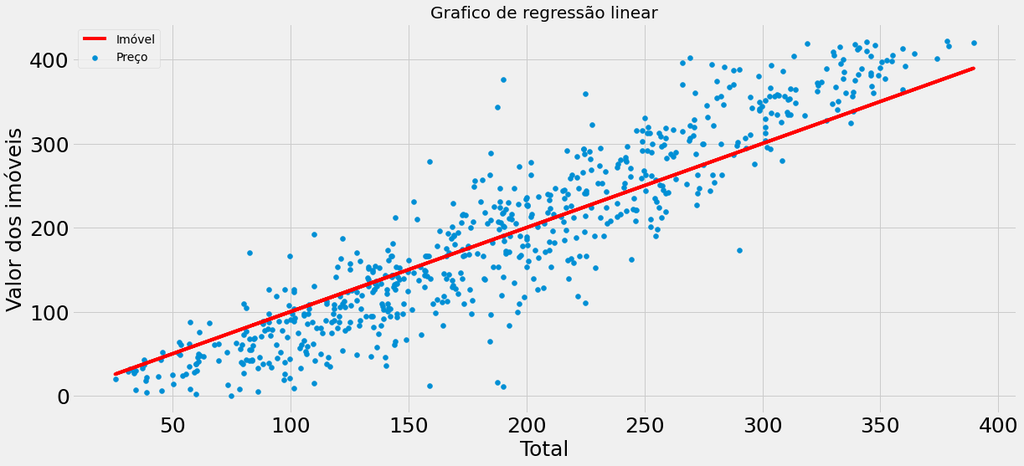

```python
# Grafico de regressão linear

plt.figure(figsize=(18, 8))
plt.scatter(pred, y_train)
plt.plot(pred, model_random_forest_regressor.predict(x_train), color = "red")
plt.title("Grafico de regressão linear", fontsize = 20)
plt.xlabel("Total")
plt.xlabel("Total")
plt.ylabel("Valor dos imóveis")
plt.legend(["Imóvel", "Preço"])
```

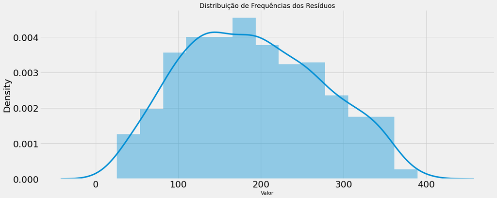

```python
# Gráfico de distribuição Frequências

ax = sns.distplot(pred)
ax.figure.set_size_inches(20, 8)
ax.set_title('Distribuição de Frequências dos Resíduos', fontsize=18)
ax.set_xlabel('Valor', fontsize=14)
ax
```

# 15) Métricas para o modelo 2 Random Forest Regressor

- RMSE: Raiz do erro quadrático médio
- MAE: Erro absoluto médio
- MSE: Erro médio quadrático
- MAPE: Erro Percentual Absoluto Médio
- R2: O R-Quadrado, ou Coeficiente de Determinação, é uma métrica que visa expressar a quantidade da variança dos dados.

```python
rmse = np.sqrt(mean_squared_error(y_test, model_random_forest_regressor_pred))
mae = mean_absolute_error(y_test, model_random_forest_regressor_pred)
mape = mean_absolute_percentage_error(y_test, model_random_forest_regressor_pred)
mse = mean_squared_error(y_test, model_random_forest_regressor_pred)
r2 = r2_score(y_test, model_random_forest_regressor_pred)

pd.DataFrame([rmse, mae, mse, mape, r2], ['RMSE', 'MAE', 'MSE', "MAPE",'R²'], columns=['Resultado'])
```

|  | Resultado |
| --- | --- |
| RMSE | 104.345469 |
| MAE | 81.393967 |
| MSE | 10887.976873 |
| MAPE | 1.543478 |
| R² | -0.001162 |

```python
# Previsão de imóvel

prev = x_test[0:25]
model_pred = model_random_forest_regressor.predict(prev)[0]
print("Previsão valor do imóvel", model_pred)
prev
```

```
Previsão valor do imóvel 157.445
```

|  | Lot.Area | Yr.Sold |
| --- | --- | --- |
| 806 | 21 | 2 |
| 202 | 600 | 2 |
| 55 | 105 | 1 |
| 479 | 406 | 4 |
| 27 | 154 | 0 |
| 14 | 57 | 1 |
| 451 | 608 | 0 |
| 492 | 391 | 0 |
| 247 | 507 | 1 |
| 789 | 314 | 0 |
| 625 | 42 | 1 |
| 745 | 572 | 2 |
| 8 | 345 | 3 |
| 222 | 460 | 1 |
| 584 | 106 | 4 |
| 737 | 167 | 1 |
| 477 | 78 | 4 |
| 101 | 231 | 4 |
| 113 | 34 | 4 |
| 267 | 636 | 0 |
| 681 | 485 | 0 |
| 503 | 353 | 1 |
| 77 | 554 | 0 |
| 453 | 135 | 2 |
| 491 | 344 | 4 |

# 16) Modelo 03 - KNN Regressor

```python
from sklearn.neighbors import KNeighborsRegressor

modelo_KNN_regressor = KNeighborsRegressor(n_neighbors = 30, metric = 'euclidean')
modelo_KNN_regressor_fit = modelo_KNN_regressor.fit(x_train, y_train)
modelo_KNN_regressor_score = modelo_KNN_regressor.score(x_train, y_train)

print("Modelo - K-NN regressor score: %.2f" % (modelo_KNN_regressor_score * 100))
```

```
Modelo - K-NN regressor score: 24.11
```

```python
modelo_KNN_regressor_pred = modelo_KNN_regressor.predict(x_test)
modelo_KNN_regressor_pred
```

```
array([148.73333333, 276.33333333, 108.16666667, 210.66666667,
       174.66666667, 159.4       , 260.4       , 201.86666667,
       257.16666667, 192.23333333, 178.        , 278.63333333,
       171.53333333, 253.23333333, 108.16666667, 175.56666667,
       109.6       , 151.13333333, 178.        , 261.93333333,
       235.86666667, 186.73333333, 248.        , 148.46666667,
       172.43333333, 164.63333333, 261.93333333, 137.73333333,
       265.9       , 164.9       , 148.6       , 248.        ,
       180.56666667, 206.8       , 186.3       , 277.8       ,
       260.9       , 218.56666667, 141.86666667, 173.83333333,
       159.26666667, 207.36666667, 197.93333333, 148.7       ,
       175.46666667, 131.16666667, 233.03333333, 186.33333333,
       282.56666667, 147.4       , 177.13333333, 155.26666667,
       147.4       ,  94.33333333, 192.2       , 230.7       ,
       261.06666667, 267.53333333, 177.9       , 140.76666667,
       267.53333333, 214.53333333, 240.7       ,  99.76666667,
       241.86666667, 166.76666667, 258.63333333, 177.        ,
       130.76666667, 179.83333333, 232.23333333, 253.3       ,
        92.36666667, 170.86666667, 148.46666667, 253.3       ,
       115.23333333, 181.16666667, 134.9       , 109.4       ,
       164.96666667, 227.66666667, 256.16666667, 208.1       ,
       283.9       , 148.46666667, 149.6       , 230.53333333,
       266.06666667, 253.63333333, 129.46666667, 182.53333333,
       273.06666667, 162.5       , 268.5       , 190.76666667,
        92.36666667, 152.86666667,  86.66666667, 242.43333333,
       140.06666667, 235.        , 186.73333333, 191.73333333,
       161.3       , 145.1       , 220.76666667, 148.46666667,
       216.16666667, 192.56666667, 176.2       , 129.23333333,
        92.33333333, 236.16666667, 208.16666667, 262.7       ,
       230.53333333,  99.5       , 140.76666667, 120.3       ,
       137.7       , 108.7       , 148.06666667, 148.56666667,
       205.7       , 251.83333333, 161.63333333, 105.63333333,
       219.23333333, 252.5       , 267.53333333, 220.36666667,
       259.93333333, 148.46666667, 194.96666667, 267.53333333,
       284.4       , 138.26666667, 146.5       , 196.33333333,
       256.46666667, 179.06666667, 258.7       , 241.4       ,
       170.9       , 219.7       , 159.26666667, 164.2       ,
        99.76666667, 197.36666667, 111.56666667, 137.2       ,
        99.76666667, 243.46666667, 159.36666667, 267.53333333,
       126.6       , 190.73333333, 197.93333333, 267.53333333,
       175.26666667, 278.53333333,  86.66666667, 145.96666667])
```

```python
# O coeficiente de determinação (R²) é uma medida resumida que diz quanto a linha de regressão ajusta-se aos dados.
# É um valor entra 0 e 1.

print('R² = {}'.format(modelo_KNN_regressor.score(x_train, y_train).round(2)))
```

```
R² = 0.24
```

```python
# Previsão do modelo
pred = modelo_KNN_regressor.predict(x_train)
pred2 = y_train - pred
pred2
```

```
172    -66.600000
48     -55.966667
319     67.433333
627    -89.033333
320     64.833333
          ...
763    -58.233333
192    -46.700000
629     72.966667
559      1.033333
684   -120.733333
Name: price, Length: 653, dtype: float64
```

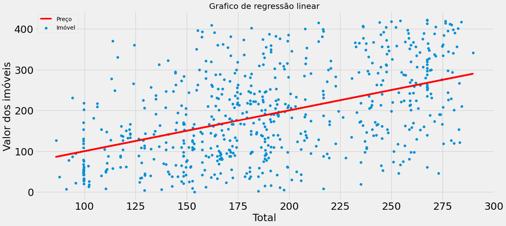

```python
# Grafico de regressão linear

plt.figure(figsize=(18, 8))
plt.scatter(pred, y_train)
plt.plot(pred, modelo_KNN_regressor.predict(x_train), color = "red")
plt.title("Grafico de regressão linear", fontsize = 20)
plt.xlabel("Total")
plt.xlabel("Total")
plt.ylabel("Valor dos imóveis")
plt.legend(["Preço", "Imóvel"])
```

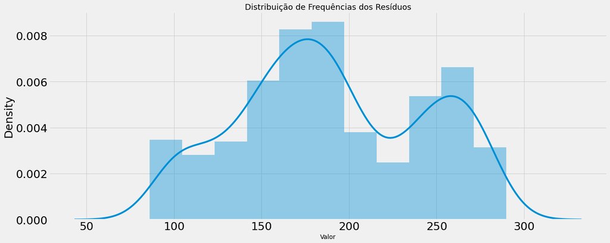

```python
# Gráfico de distribuição Frequências

ax = sns.distplot(pred)
ax.figure.set_size_inches(20, 8)
ax.set_title('Distribuição de Frequências dos Resíduos', fontsize=18)
ax.set_xlabel('Valor', fontsize=14)
ax
```

# 17) Métricas para o modelo 3 K-NN Regressor

- RMSE: Raiz do erro quadrático médio
- MAE: Erro absoluto médio
- MSE: Erro médio quadrático
- MAPE: Erro Percentual Absoluto Médio
- R2: O R-Quadrado, ou Coeficiente de Determinação, é uma métrica que visa expressar a quantidade da variança dos dados.

```python
rmse = np.sqrt(mean_squared_error(y_test, modelo_KNN_regressor_pred))
mae = mean_absolute_error(y_test, modelo_KNN_regressor_pred)
mape = mean_absolute_percentage_error(y_test, modelo_KNN_regressor_pred)
mse = mean_squared_error(y_test, modelo_KNN_regressor_pred)
r2 = r2_score(y_test, modelo_KNN_regressor_pred)

pd.DataFrame([rmse, mae, mse, mape, r2], ['RMSE', 'MAE', 'MSE', "MAPE",'R²'], columns=['Resultado'])
```

|  | Resultado |
| --- | --- |
| RMSE | 95.306166 |
| MAE | 77.264228 |
| MSE | 9083.265339 |
| MAPE | 1.863952 |
| R² | 0.164783 |

```python
# Previsão de imóvel

prev = x_test[0:25]
model_pred = modelo_KNN_regressor.predict(prev)[0]
print("Previsão de imóvel", model_pred)
prev
```

```
Previsão de imóvel 148.73333333333332
```

|  | Lot.Area | Yr.Sold |
| --- | --- | --- |
| 806 | 21 | 2 |
| 202 | 600 | 2 |
| 55 | 105 | 1 |
| 479 | 406 | 4 |
| 27 | 154 | 0 |
| 14 | 57 | 1 |
| 451 | 608 | 0 |
| 492 | 391 | 0 |
| 247 | 507 | 1 |
| 789 | 314 | 0 |
| 625 | 42 | 1 |
| 745 | 572 | 2 |
| 8 | 345 | 3 |
| 222 | 460 | 1 |
| 584 | 106 | 4 |
| 737 | 167 | 1 |
| 477 | 78 | 4 |
| 101 | 231 | 4 |
| 113 | 34 | 4 |
| 267 | 636 | 0 |
| 681 | 485 | 0 |
| 503 | 353 | 1 |
| 77 | 554 | 0 |
| 453 | 135 | 2 |
| 491 | 344 | 4 |

# 18) Modelo 04 - Decision Tree Regressor

```python
from sklearn.tree import DecisionTreeRegressor

model_decision_tree_regressor = DecisionTreeRegressor(random_state = 30)
model_decision_tree_regressor_fit = model_decision_tree_regressor.fit(x_train, y_train)
model_decision_tree_regressor_score = model_decision_tree_regressor.score(x_train, y_train)

print("Modelo - Decision tree regressor score: %.2f" % (model_decision_tree_regressor_score * 100))
```

```
Modelo - Decision tree regressor score: 95.61
```

```python
model_decision_tree_regressor_pred = model_decision_tree_regressor.predict(x_test)
model_decision_tree_regressor_pred
```

```
array([166.  , 419.  ,  48.  , 128.  , 166.  , 104.  , 319.  , 103.  ,
       153.  , 190.  , 215.  ,  46.  , 244.  , 117.  , 125.  ,  88.  ,
        88.  , 138.  , 166.  , 347.  , 171.  , 329.  , 364.  ,  89.  ,
        38.  , 166.  , 367.  ,  66.  , 307.  , 140.  , 322.  , 364.  ,
        60.  , 291.  , 139.  , 226.  , 420.  , 271.  , 247.  , 108.  ,
       145.5 , 143.  ,  78.  ,  70.  , 170.5 , 130.  , 292.  , 110.  ,
       398.  ,  26.  , 129.  , 263.  , 138.5 ,  18.  ,  92.  , 279.  ,
       117.  , 235.  , 244.  , 141.  , 413.  , 271.  , 153.  ,  30.  ,
       110.  , 240.  , 212.  ,  96.  , 143.  , 272.  , 366.  , 268.  ,
       126.  ,  75.  ,  87.75, 212.  ,  71.  ,  92.  , 141.  ,  52.  ,
       113.  ,  84.  , 404.  , 227.  , 361.  ,  93.5 , 205.  , 348.  ,
       208.  , 117.  ,  45.  , 292.  , 153.  ,  38.  , 347.  , 115.  ,
        37.  , 145.5 ,  37.  , 166.  ,  66.  , 218.  ,  92.  , 207.  ,
       259.  , 244.  , 304.  ,  87.75,  50.  , 141.5 , 167.  ,   4.  ,
        13.  , 366.  , 233.  , 188.  , 134.  ,  51.  , 141.  , 150.  ,
       152.  , 181.  , 207.  , 207.  , 123.  , 198.  , 210.  , 181.  ,
       239.  ,  46.  , 422.  , 321.  , 205.  ,  93.5 , 329.  , 288.  ,
       342.  , 237.  , 207.  , 110.  , 114.  , 190.  , 224.  , 377.  ,
       207.  , 118.  , 321.  , 253.  ,  27.  ,  78.  , 181.  ,  44.  ,
        30.  , 292.  , 166.  , 421.  ,  89.  , 190.  , 345.  , 421.  ,
       303.  , 419.  ,  37.  , 206.  ])
```

```python
# O coeficiente de determinação (R²) é uma medida resumida que diz quanto a linha de regressão ajusta-se aos dados.
# É um valor entra 0 e 1.

print('R² = {}'.format(model_decision_tree_regressor.score(x_train, y_train).round(2)))
```

```
R² = 0.96
```

```python
# Previsão do modelo
pred = model_decision_tree_regressor.predict(x_train)
pred2 = y_train - pred
pred2
```

```
172     0.000000
48      0.000000
319     0.000000
627     0.000000
320     0.000000
         ...
763    17.666667
192     0.000000
629    25.000000
559     0.000000
684     0.000000
Name: price, Length: 653, dtype: float64
```

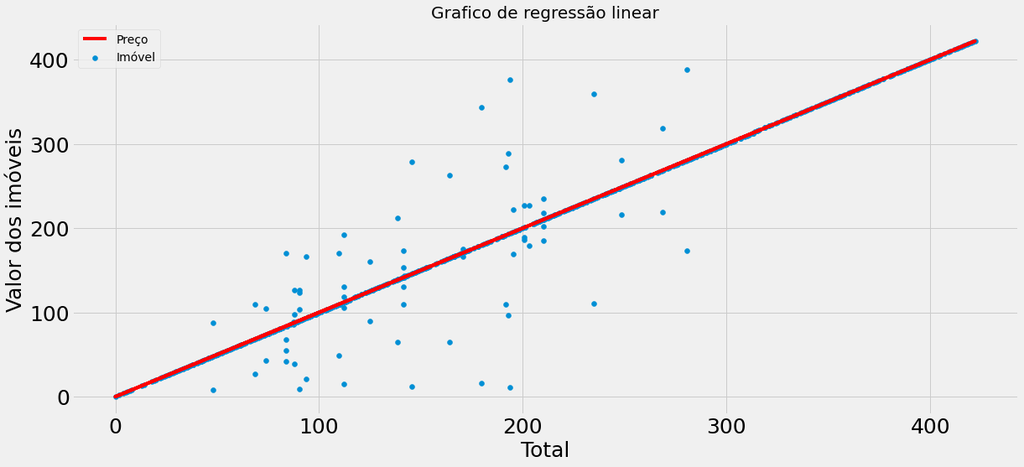

```python
# Grafico de regressão linear

plt.figure(figsize=(18, 8))
plt.scatter(pred, y_train)
plt.plot(pred, model_decision_tree_regressor.predict(x_train), color = "red")
plt.title("Grafico de regressão linear", fontsize = 20)
plt.xlabel("Total")
plt.xlabel("Total")
plt.ylabel("Valor dos imóveis")
plt.legend(["Preço", "Imóvel"])
```

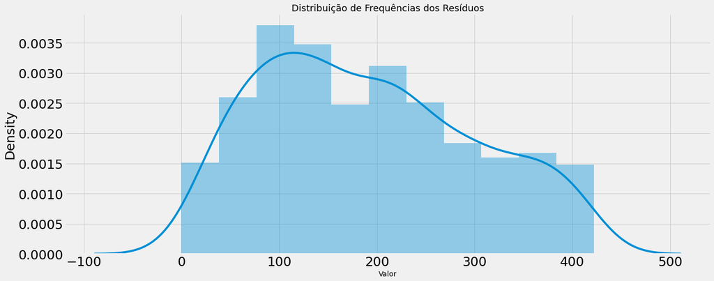

```python
# Gráfico de distribuição Frequências

ax = sns.distplot(pred)
ax.figure.set_size_inches(20, 8)
ax.set_title('Distribuição de Frequências dos Resíduos', fontsize=18)
ax.set_xlabel('Valor', fontsize=14)
ax
```